# quarto-input54ed1fba

```r
library(tidyverse)
library(readr)
library(stringr)
library(dplyr)
library(tidyr)
library(VennDiagram)
library(purrr)
library(dplyr)
library(ggplot2)
library(patchwork)
library(viridis)
library(ggridges)
library(cowplot)
library(ggrepel)
library(scales)
library(broom)
source("../R/99_proj_func.R")
```

```r
quarto::quarto_render(input = "../R/01_load.qmd")
```

[output not shown]

```r
file.rename(from = "../R/01_load.html",
            to = "../results/01_load.html")
```

```
[1] TRUE
```

```r
quarto::quarto_render(input = "../R/02_clean.qmd")
```

[output not shown]

[output cut: 13 more lines]

[output not shown]

```r
file.rename(from = "../R/02_clean.html",
            to = "../results/02_clean.html")
```

```
[1] TRUE
```

```r
quarto::quarto_render(input = "../R/03_augment.qmd")
```

[output not shown]

```r
file.rename(from = "../R/03_augment.html",
            to = "../results/03_augment.html")
```

```
[1] TRUE
```

```r
quarto::quarto_render(input = "../R/04_describe.qmd")
```

[output not shown]

[output cut: 20 more lines]

[output not shown]

```r
file.rename(from = "../R/04_describe.html",
            to = "../results/04_describe.html")
```

```
[1] TRUE
```

```r
quarto::quarto_render(input = "../R/05_analysis_1.qmd")
```

[output not shown]

```r
file.rename(from = "../R/05_analysis_1.html",
            to = "../results/05_analysis_1.html")
```

```
[1] TRUE
```

```r
quarto::quarto_render(input = "../R/06_analysis_2.qmd")
```

[output not shown]

```r
file.rename(from = "../R/06_analysis_2.html",
            to = "../results/06_analysis_2.html")
```

```
[1] TRUE
```

```r
quarto::quarto_render(input = "../R/07_analysis_3.qmd")
```

[output not shown]

```r
file.rename(from = "../R/07_analysis_3.html",
            to = "../results/07_analysis_3.html")
```

```
[1] TRUE
```

## Load

```r
#Load the necessary libraries for data handling and manipulation


library(tidyverse)
library(readr)
source("../R/99_proj_func.R") #Custom functions created by us
```

```r
# Generates data folder and _raw sub folder
generate_dir() #call function to generate the directory
```

```r
# Here we define the URLs for downloading human and mouse data files

human_file <- "https://raw.githubusercontent.com/s232996/project/main/gCSI_GRdata_v1.3.tsv/data/human.csv"

human_suppl_file <- "https://raw.githubusercontent.com/s232996/project/main/gCSI_GRdata_v1.3.tsv/data/human_suppl.txt"

mouse_file <- "https://raw.githubusercontent.com/s232996/project/main/gCSI_GRdata_v1.3.tsv/data/mouse.csv"

mouse_suppl_file <- "https://raw.githubusercontent.com/s232996/project/main/gCSI_GRdata_v1.3.tsv/data/mouse_suppl.txt"
```

```r
#The following functions download the files and saves them in #the data correct folders

human_data <- download_csv(human_file, "01_dat_load_human")
mouse_data <- download_csv(mouse_file, "01_dat_load_mouse")

human_suppl_data <- download_txt(human_suppl_file, "01_dat_load_human_suppl")
mouse_suppl_data <- download_txt(mouse_suppl_file, "01_dat_load_mouse_suppl")
```

```r
#Combine downloaded data into a list for further processing


data_list <- list(human_data, human_suppl_data, mouse_data, mouse_suppl_data)

head_all(data_list)# display the head of every dataset contained in the datalist
```

```
[[1]]
# A tibble: 6 × 38
  gene_id      symbol A375.DMSO A375.G007.LK FemxI.DMSO FemxI.G007.LK FemxV.DMSO
  <chr>        <chr>      <dbl>        <dbl>      <dbl>         <dbl>      <dbl>
1 ENSG0000000… TSPAN6     15.6         15.6       21.8        22.2         22.7
2 ENSG0000000… TNMD        0            0          0           0            0
3 ENSG0000000… DPM1      150.         169.        88.1        87.1         62.1
4 ENSG0000000… SCYL3       7.09         6.04       4.69        5.65         3.79
5 ENSG0000000… C1orf…     24.1         22.6       24.5        26.8         22.8
6 ENSG0000000… FGR         0            0          0           0.0102       0
# ℹ 31 more variables: FemxV.G007.LK <dbl>, LOX.DMSO <dbl>, LOX.G007.LK <dbl>,
#   MeWo.DMSO <dbl>, MeWo.G007.LK <dbl>, Skmel28.DMSO <dbl>,
#   Skmel28.G007.LK <dbl>, WM115.DMSO <dbl>, WM115.G007.LK <dbl>,
#   WM1341.DMSO <dbl>, WM1341.G007.LK <dbl>, WM1366.DMSO <dbl>,
#   WM1366.G007.LK <dbl>, WM1382.DMSO <dbl>, WM1382.G007.LK <dbl>,
#   WM239.DMSO <dbl>, WM239.G007.LK <dbl>, WM266.DMSO <dbl>,
#   WM266.G007.LK <dbl>, WM35.DMSO <dbl>, WM35.G007.LK <dbl>, …

[[2]]
# A tibble: 6 × 28
  `Source Name` `Characteristics[organism]` Characteristics[developmental stag…¹
  <chr>         <chr>                       <chr>
1 A375.DMSO     Homo sapiens                adult
2 LOX.DMSO      Homo sapiens                adult
3 Skmel28.DMSO  Homo sapiens                adult
4 WM115.DMSO    Homo sapiens                adult
5 WM1341.DMSO   Homo sapiens                adult
6 WM239.DMSO    Homo sapiens                adult
# ℹ abbreviated name: ¹`Characteristics[developmental stage]`
# ℹ 25 more variables: `Characteristics[disease]` <chr>,
#   `Characteristics[genotype]` <chr>, `Characteristics[organism part]` <chr>,
#   `Characteristics[cell line]` <chr>, `Material Type` <chr>,
#   `Protocol REF...9` <chr>, `Protocol REF...10` <chr>,
#   `Protocol REF...11` <chr>, Performer...12 <chr>, `Extract Name` <chr>,
#   `Comment[LIBRARY_LAYOUT]` <chr>, `Comment[LIBRARY_SELECTION]` <chr>, …

[[3]]
# A tibble: 6 × 14
  gene_id     symbol `DMSO-1` `DMSO-2` `DMSO-3` `G007LK-1` `G007LK-2` `G007LK-3`
  <chr>       <chr>     <dbl>    <dbl>    <dbl>      <dbl>      <dbl>      <dbl>
```

[output cut: 11 more lines]

```
  `Source Name` `Comment[ENA_SAMPLE]` `Comment[BioSD_SAMPLE]`
  <chr>         <chr>                 <chr>
1 DMSO-1        ERS3548927            SAMEA5745642
2 DMSO-1        ERS3548927            SAMEA5745642
3 DMSO-2        ERS3548928            SAMEA5745643
4 DMSO-2        ERS3548928            SAMEA5745643
5 DMSO-3        ERS3548929            SAMEA5745644
6 DMSO-3        ERS3548929            SAMEA5745644
# ℹ 31 more variables: `Characteristics[organism]` <chr>,
#   `Characteristics[disease]` <chr>, `Characteristics[organism part]` <chr>,
#   `Characteristics[cell line]` <chr>, Provider <chr>, `Material Type` <chr>,
#   `Protocol REF...10` <chr>, `Protocol REF...11` <chr>,
#   `Protocol REF...12` <chr>, Performer...13 <chr>, `Extract Name` <chr>,
#   `Comment[LIBRARY_LAYOUT]` <chr>, `Comment[LIBRARY_SELECTION]` <chr>,
#   `Comment[LIBRARY_SOURCE]` <chr>, `Comment[LIBRARY_STRATEGY]` <chr>, …
```

## Clean

```r
library(tidyverse)
library(stringr)
library(dplyr)
library(tidyr)
source("../R/99_proj_func.R")

#mouse datasets
mouse_data <- read_tsv(file = "../data/01_dat_load_mouse.tsv.gz")
mouse_suppl_data <- read_tsv(file = "../data/01_dat_load_mouse_suppl.tsv.gz")

#human_datasets
human_data <- read_tsv(file = "../data/01_dat_load_human.tsv.gz")
human_suppl_data <- read_tsv(file = "../data/01_dat_load_human_suppl.tsv.gz")

data_list <- list(mouse_data, mouse_suppl_data,human_data, human_suppl_data)
```

First we need to see how the data are represented

```
# A tibble: 10 × 14
   gene_id    symbol `DMSO-1` `DMSO-2` `DMSO-3` `G007LK-1` `G007LK-2` `G007LK-3`
   <chr>      <chr>     <dbl>    <dbl>    <dbl>      <dbl>      <dbl>      <dbl>
 1 ENSMUSG00… GNAI3    75.0    76.6       54.9       74.9       70.0       59.2
 2 ENSMUSG00… PBSN      0       0          0          0          0          0
 3 ENSMUSG00… CDC45    48.8    55.6       49.9       50.4       57.7       49.6
 4 ENSMUSG00… SCML2     1.20    2.81       3.15       1.39       2.50       4.34
 5 ENSMUSG00… APOH      0.178   0.0621     0          0          0          0
 6 ENSMUSG00… NARF      8.30    8.14      14.5       11.0        8.86      22.1
 7 ENSMUSG00… CAV2    141.    112.        77.5      142.       107.        89.8
 8 ENSMUSG00… KLF6     45.8    37.8       45.5       48.4       36.3       45.4
 9 ENSMUSG00… SCMH1    23.1    17.4       19.4       20.3       20.3       17.2
10 ENSMUSG00… COX5A   493.    518.       452.       488.       515.       436.
# ℹ 6 more variables: `WNT-1` <dbl>, `WNT-2` <dbl>, `WNT-3` <dbl>,
#   `WNT_G007LK-1` <dbl>, `WNT_G007LK-2` <dbl>, `WNT_G007LK-3` <dbl>
```

```
# A tibble: 10 × 38
   gene_id     symbol A375.DMSO A375.G007.LK FemxI.DMSO FemxI.G007.LK FemxV.DMSO
   <chr>       <chr>      <dbl>        <dbl>      <dbl>         <dbl>      <dbl>
 1 ENSG000000… TSPAN6    15.6         15.6      21.8         22.2         22.7
 2 ENSG000000… TNMD       0            0         0            0            0
 3 ENSG000000… DPM1     150.         169.       88.1         87.1         62.1
 4 ENSG000000… SCYL3      7.09         6.04      4.69         5.65         3.79
 5 ENSG000000… C1orf…    24.1         22.6      24.5         26.8         22.8
 6 ENSG000000… FGR        0            0         0            0.0102       0
 7 ENSG000000… CFH        0.967        0.776     0.0366       0.00739      0.128
 8 ENSG000000… FUCA2     24.7         25.4      38.9         38.8         43.9
 9 ENSG000000… GCLC      34.2         24.1      23.8         29.8         29.0
10 ENSG000000… NFYA      20.0         16.4      19.8         20.1         19.7
# ℹ 31 more variables: FemxV.G007.LK <dbl>, LOX.DMSO <dbl>, LOX.G007.LK <dbl>,
#   MeWo.DMSO <dbl>, MeWo.G007.LK <dbl>, Skmel28.DMSO <dbl>,
#   Skmel28.G007.LK <dbl>, WM115.DMSO <dbl>, WM115.G007.LK <dbl>,
#   WM1341.DMSO <dbl>, WM1341.G007.LK <dbl>, WM1366.DMSO <dbl>,
#   WM1366.G007.LK <dbl>, WM1382.DMSO <dbl>, WM1382.G007.LK <dbl>,
#   WM239.DMSO <dbl>, WM239.G007.LK <dbl>, WM266.DMSO <dbl>,
#   WM266.G007.LK <dbl>, WM35.DMSO <dbl>, WM35.G007.LK <dbl>, …
```

### Check for the possible NAs in the 4 data sets

```r
walk(data_list, nas_present)
```

```
There are no NA values in the data frame.
There are no NA values in the data frame.
There are no NA values in the data frame.
There are no NA values in the data frame.
```

First of all we observe that none of the data sets contain any missing values

### **Mouse data set description:**

Looking at this data set we can see that it represents the experimental compounds as variables and lists genes by their assembly abbreviations and their common name as rows. Each cell in the data set holds the expression levels of individual genes within the B16-F10 cell line. To optimize the utilization of this data set we can perform a tidy procedure.

### **Human data set description:**

This data set comprises of a gene id, a column containing common gene name and multiple columns representing the cell lines that were used for the experiment combined with their treatment status. This data set also requires some cleaning before analyzing it.

# Mouse data sets

### Mouse data cleaning

Converting to long format

```r
# Convert to long format

mouse_data_long <- mouse_data |>
  pivot_longer(
    cols = -c(gene_id, symbol),
    names_to = "treatment_replicate",
    values_to = "expression_levels"
  )

# Separate the treatment and replicate information
mouse_data_separated_repl <- mouse_data_long |>
  separate(
    col = treatment_replicate,
    into = c("treatment", "replicate"),
    sep = "-"
    )
```

```r
mouse_clean <- mouse_data_separated_repl |>
# The symbol variable does not provide us with addtional information so we are going to drop it
  select(-symbol) |>
  pivot_wider(names_from = gene_id,
              values_from = expression_levels
              )
```

```
# A tibble: 12 × 10
   treatment  replicate ENSMUSG00000000001 ENSMUSG00000000003 ENSMUSG00000000028
   <chr>      <chr>                  <dbl>              <dbl>              <dbl>
 1 DMSO       1                       75.0                  0               48.8
 2 DMSO       2                       76.6                  0               55.6
 3 DMSO       3                       54.9                  0               49.9
 4 G007LK     1                       74.9                  0               50.4
 5 G007LK     2                       70.0                  0               57.7
 6 G007LK     3                       59.2                  0               49.6
 7 WNT        1                       74.9                  0               49.5
 8 WNT        2                       73.4                  0               51.4
 9 WNT        3                       57.3                  0               47.4
10 WNT_G007LK 1                       74.1                  0               47.9
11 WNT_G007LK 2                       71.7                  0               53.1
12 WNT_G007LK 3                       68.3                  0               44.2
# ℹ 5 more variables: ENSMUSG00000000037 <dbl>, ENSMUSG00000000049 <dbl>,
#   ENSMUSG00000000056 <dbl>, ENSMUSG00000000058 <dbl>,
#   ENSMUSG00000000078 <dbl>
```

After the cleaning process the resulting format presents various treatments as rows with replicate number and gene_ids as variables.

### Supplementary mouse data cleaning

Upon inspection of the data set it is seen that most supplementary data consists of metadata concerning the experiment that do not vary between the individual drug experiments.

```r
# Clean the column names from the mouse supplementary data set

mouse_suppl_clean <-mouse_suppl_data |>
  janitor::clean_names() |>
  rename_with(
    ~ str_remove(., "characteristics_"),# remove the characteristics_ from the column names
    starts_with("characteristics_"),
  ) |>
  rename_with(
       ~str_remove(., "comment_"), #remove the comment_ from the column names
    starts_with("comment_")
  )
```

```r
# Some extra cleaning with the variable factor_value_compound

mouse_suppl_clean <- mouse_suppl_clean |>
  mutate(
    factor_value_compound= case_when(
      factor_value_compound == "dimethyl sulfoxide (0.1 percent)" ~ "0.1%",
      factor_value_compound == "G007LK (1 micromolar)" ~ "1μM",
      factor_value_compound == "WNT3a (0.5 microgram per milliliter)" ~ "0.5mg/ml ",
      factor_value_compound == "WNT3a (0.5 microgram per milliliter); G007LK (1 micromolar)" ~ "0.5mg/ml; 1μΜ",
      TRUE ~ factor_value_compound) # keep the original value of the compound_dose column if the conditions are not met
    )|>
  rename(compound_dose = factor_value_compound) |>
  #get rid of the redundant columns
  select(-c(extract_name, assay_name)) #those two columns contain the same information as the source_name
```

```
# A tibble: 10 × 32
   source_name ena_sample bio_sd_sample organism disease organism_part cell_line
   <chr>       <chr>      <chr>         <chr>    <chr>   <chr>         <chr>
 1 DMSO-1      ERS3548927 SAMEA5745642  Mus mus… melano… skin          B16-F10 …
 2 DMSO-1      ERS3548927 SAMEA5745642  Mus mus… melano… skin          B16-F10 …
 3 DMSO-2      ERS3548928 SAMEA5745643  Mus mus… melano… skin          B16-F10 …
 4 DMSO-2      ERS3548928 SAMEA5745643  Mus mus… melano… skin          B16-F10 …
 5 DMSO-3      ERS3548929 SAMEA5745644  Mus mus… melano… skin          B16-F10 …
 6 DMSO-3      ERS3548929 SAMEA5745644  Mus mus… melano… skin          B16-F10 …
 7 G007LK-1    ERS3548930 SAMEA5745645  Mus mus… melano… skin          B16-F10 …
 8 G007LK-1    ERS3548930 SAMEA5745645  Mus mus… melano… skin          B16-F10 …
 9 G007LK-2    ERS3548931 SAMEA5745646  Mus mus… melano… skin          B16-F10 …
10 G007LK-2    ERS3548931 SAMEA5745646  Mus mus… melano… skin          B16-F10 …
# ℹ 25 more variables: provider <chr>, material_type <chr>,
#   protocol_ref_10 <chr>, protocol_ref_11 <chr>, protocol_ref_12 <chr>,
#   performer_13 <chr>, library_layout <chr>, library_selection <chr>,
#   library_source <chr>, library_strategy <chr>, nominal_length <dbl>,
#   nominal_sdev <dbl>, protocol_ref_21 <chr>, performer_22 <chr>,
#   technology_type <chr>, ena_experiment <chr>, scan_name <chr>,
#   submitted_file_name <chr>, ena_run <chr>, fastq_uri <chr>, …
```

That is it for the cleaning process of the mouse data and supplementary mouse data.

```r
# # Write the two clean data sets to tsv files
write_tsv(x = mouse_clean,
          file = ("../data/02_dat_clean_mouse.tsv.gz"))
write_tsv(x = mouse_suppl_clean,
          file = ("../data/02_dat_clean_mouse_suppl.tsv.gz"))
```

## Human data sets

This data set is also untidy. Therefore we are going to transform it via pivoting longer. But before proceeding, it is evident that the column names contain two pieces of information, the cell line and the compound used in each experiment. Therefore we have to split these two.

This is our approach of doing that:

```r
human_trans <-human_data |>
  rename_with(
    ~case_when(
      #We see that the columns containing the cell lines contain the name of the cell lines and the DMSO or G007.LK compounds separated by a "."
       str_detect(., ".DMSO") ~ str_replace_all(.,
                                             ".DMSO",
                                             "_DMSO"),
       str_detect(., ".G007.LK") ~ str_replace_all(.,
                                                ".G007.LK",
                                                "_G007LK"),
       TRUE ~ .  # keep the original name of the columns if the aforementioned conditions are not met
     )
   )
```

```r
# Pivot the human dataframe
human_clean_long <- human_trans |>
  pivot_longer(
    cols = -(gene_id:symbol),
    names_to = c("cell_line",
                 "treatment"),
    values_to = "expression_levels",
    names_sep = "_"
      )|>
  select(-symbol) # we exclude the symbol for the same reason we did when we were cleaning the mouse dataset
```

Now we are going to finish our cleaning process by getting back to wide format but with the different genes as variables in the column names

```r
human_clean <- human_clean_long |>
  pivot_wider(
    names_from = gene_id,
    values_from = expression_levels
  )
```

```
# A tibble: 10 × 39,077
   cell_line treatment ENSG00000000003 ENSG00000000005 ENSG00000000419
   <chr>     <chr>               <dbl>           <dbl>           <dbl>
 1 A375      DMSO                 15.6               0           150.
 2 A375      G007LK               15.6               0           169.
 3 FemxI     DMSO                 21.8               0            88.1
 4 FemxI     G007LK               22.2               0            87.1
 5 FemxV     DMSO                 22.7               0            62.1
 6 FemxV     G007LK               22.8               0            76.3
 7 LOX       DMSO                 21.6               0            62.9
 8 LOX       G007LK               23.6               0            71.1
 9 MeWo      DMSO                 12.3               0           104.
10 MeWo      G007LK               12.8               0            93.9
# ℹ 39,072 more variables: ENSG00000000457 <dbl>, ENSG00000000460 <dbl>,
#   ENSG00000000938 <dbl>, ENSG00000000971 <dbl>, ENSG00000001036 <dbl>,
#   ENSG00000001084 <dbl>, ENSG00000001167 <dbl>, ENSG00000001460 <dbl>,
#   ENSG00000001461 <dbl>, ENSG00000001497 <dbl>, ENSG00000001561 <dbl>,
#   ENSG00000001617 <dbl>, ENSG00000001626 <dbl>, ENSG00000001629 <dbl>,
#   ENSG00000001630 <dbl>, ENSG00000001631 <dbl>, ENSG00000002016 <dbl>,
#   ENSG00000002079 <dbl>, ENSG00000002330 <dbl>, ENSG00000002549 <dbl>, …
```

Now we are going to clean the supplementary human file.

The source name column has the same format as the columns we pivoted before and separated them into cell_line and compound columns.

```r
#Clean the column names from the human supplementary data
human_suppl_clean <- human_suppl_data |>
  janitor::clean_names() |>
  rename_with(
    ~ str_remove(., "characteristics_"),
    starts_with("characteristics_")
  ) |>
   rename_with(
       ~str_remove(., "comment_"),
    starts_with("comment_")
    )
```

```r
# We separate the first column
# We notice an inconsistency with the names of the cell lines which creates some problems when we try to separate the two components of the first column

human_suppl_clean_change_treat <- human_suppl_clean |>
  mutate(source_name =
  case_when(
      #We see that the column source name contains the name of the cell lines and the compounds separated by a "."
       str_detect(source_name, "\\.DMSO$") ~ str_replace(source_name,
                                                         "\\.DMSO",
                                                         "_DMSO"),
       str_detect(source_name, "\\.G007.LK") ~ str_replace(source_name,
                                                           "\\.G007.LK",
                                                           "_G007LK"),
       TRUE ~ source_name  # Keep the original name of the columns if the aforementioned conditions are not met
     )#
   ) |>
  separate(source_name,
           into = c("cell_line", "treatment"),
           sep = "\\_")
```

```r
human_suppl_comp_dose <- human_suppl_clean_change_treat |>
  mutate(
    Compound_dose = str_c(factor_value_dose ,unit_dose_unit, sep = " "),
    Compound_dose = case_when(
    Compound_dose == "0.01 percent" ~ "0.01%",
    Compound_dose == "1 micromolar" ~ "1μM",
    TRUE ~ Compound_dose
      ) # Keeps the original value of the column if the condition is not met
  )|> select(
      -c(factor_value_dose,unit_dose_unit)
    )
```

```r
#Extract the redundant columns
human_suppl_clean_final <- human_suppl_comp_dose |>
  select(-c(extract_name,
            assay_name,
            factor_value_compound))
```

```
# A tibble: 10 × 24
   cell_line treatment organism     developmental_stage disease  genotype
   <chr>     <chr>     <chr>        <chr>               <chr>    <chr>
 1 A375      DMSO      Homo sapiens adult               melanoma BRAF
 2 LOX       DMSO      Homo sapiens adult               melanoma BRAF
 3 Skmel28   DMSO      Homo sapiens adult               melanoma BRAF
 4 WM115     DMSO      Homo sapiens adult               melanoma BRAF
 5 WM1341    DMSO      Homo sapiens adult               melanoma BRAF
 6 WM239     DMSO      Homo sapiens adult               melanoma BRAF
 7 WM266     DMSO      Homo sapiens adult               melanoma BRAF
 8 WM35      DMSO      Homo sapiens adult               melanoma BRAF
 9 WM45.1    DMSO      Homo sapiens adult               melanoma BRAF
10 WM793     DMSO      Homo sapiens adult               melanoma BRAF
# ℹ 18 more variables: organism_part <chr>, material_type <chr>,
#   protocol_ref_9 <chr>, protocol_ref_10 <chr>, protocol_ref_11 <chr>,
#   performer_12 <chr>, library_layout <chr>, library_selection <chr>,
#   library_source <chr>, library_strategy <chr>, protocol_ref_18 <chr>,
#   performer_19 <chr>, technology_type <chr>, protocol_ref_22 <chr>,
#   performer_23 <chr>, derived_array_data_file <chr>,
#   derived_array_express_ftp_file <chr>, Compound_dose <chr>
```

```r
# Write the two clean datasets to tsv files
write_tsv(x = human_clean,
          file = "../data/02_dat_clean_human.tsv.gz")
write_tsv(x = human_suppl_clean_final,
          file = "../data/02_dat_clean_human_suppl.tsv.gz")
```

## Augment

```r
library(tidyverse)
library(dplyr)
library(stringr)
library(tidyr)
source("../R/99_proj_func.R")

Sys.setenv(VROOM_CONNECTION_SIZE = 3062144) # Setting a larger connection buffer to be able to load the data

# Loading the clean data for the mouse and human datasets
mouse_clean <- read_tsv(file = "../data/02_dat_clean_mouse.tsv.gz")
mouse_data_suppl <- read_tsv(file = "../data/02_dat_clean_mouse_suppl.tsv.gz")
human_clean <- read_tsv(file = "../data/02_dat_clean_human.tsv.gz")
human_suppl_clean <- read_tsv(file = "../data/02_dat_clean_human_suppl.tsv.gz")
```

```
# A tibble: 10 × 35,685
   treatment  replicate ENSMUSG00000000001 ENSMUSG00000000003 ENSMUSG00000000028
   <chr>          <dbl>              <dbl>              <dbl>              <dbl>
 1 DMSO               1               75.0                  0               48.8
 2 DMSO               2               76.6                  0               55.6
 3 DMSO               3               54.9                  0               49.9
 4 G007LK             1               74.9                  0               50.4
 5 G007LK             2               70.0                  0               57.7
 6 G007LK             3               59.2                  0               49.6
 7 WNT                1               74.9                  0               49.5
 8 WNT                2               73.4                  0               51.4
 9 WNT                3               57.3                  0               47.4
10 WNT_G007LK         1               74.1                  0               47.9
# ℹ 35,680 more variables: ENSMUSG00000000037 <dbl>, ENSMUSG00000000049 <dbl>,
#   ENSMUSG00000000056 <dbl>, ENSMUSG00000000058 <dbl>,
#   ENSMUSG00000000078 <dbl>, ENSMUSG00000000085 <dbl>,
#   ENSMUSG00000000088 <dbl>, ENSMUSG00000000093 <dbl>,
#   ENSMUSG00000000094 <dbl>, ENSMUSG00000000103 <dbl>,
#   ENSMUSG00000000120 <dbl>, ENSMUSG00000000125 <dbl>,
#   ENSMUSG00000000126 <dbl>, ENSMUSG00000000127 <dbl>, …
```

## Mouse augmentation

We now create a new data frame where we “exclude” the control group experiments (DMSO) from our analysis. We do that by dividing the gene expressions of non-control values by the corresponding DMSO values within each replicate for every treatments. This transformation shifts our data set from absolute expression to relative expression. Following this transformation, we then apply log2 transformation on the relative expressions. This transformation effectively sets a baseline where a value of 0 indicates no change between the control and treatment conditions. Positive values suggest up regulation and negative values down regulation.

$$\log(expression\_treatment) - \log(expression\_control) = \log(\frac{expression\_treatment}{expression\_control (DMSO)})$$

We also calculated the local minimum observed expression for every replicate/experiment for more precise transformation of each experiment.

This is how we did it:

Firstly we excluded the genes that did not show any expression (expression levels = 0) across all replicates of all treatments

```r
test_mouse <- select(mouse_clean, -c(treatment, replicate))

zeroes_removed_mouse <- test_mouse |>
     select(where(~ !all(.x == 0)))
```

We now want to do zero replacement for the rest of the zeroes in the data set. The zeroes are an issue, since log(0) is undefined, and we would like to be able to log-transform the data. In some cases, the zeroes may suggest expression below the detection limit. Therefore, we’ve replaced the zeroes with 65% of the lowest non-zero value in the experiment. All the data is compositional so when we do the replacement, we want to make sure that the sums of each experiment is the same. We do that by rescaling everything again after replacement by dividing by the sum of rows and multiplying by 10^6.

```r
joined_mouse <- zero_replacement(zeroes_removed_mouse, mouse_clean[1:2])
```

```
# A tibble: 12 × 24,062
   treatment  replicate ENSMUSG00000000001 ENSMUSG00000000028 ENSMUSG00000000037
   <chr>          <dbl>              <dbl>              <dbl>              <dbl>
 1 DMSO               1               75.7               49.2               1.22
 2 DMSO               2               75.8               55.0               2.78
 3 DMSO               3               58.3               53.0               3.35
 4 G007LK             1               75.2               50.6               1.40
 5 G007LK             2               68.9               56.8               2.46
 6 G007LK             3               62.8               52.5               4.59
 7 WNT                1               72.5               47.9               1.11
 8 WNT                2               73.6               51.5               1.85
 9 WNT                3               59.8               49.4               2.91
10 WNT_G007LK         1               72.2               46.7               1.13
11 WNT_G007LK         2               71.2               52.7               2.20
12 WNT_G007LK         3               63.3               41.0               3.23
# ℹ 24,057 more variables: ENSMUSG00000000049 <dbl>, ENSMUSG00000000056 <dbl>,
#   ENSMUSG00000000058 <dbl>, ENSMUSG00000000078 <dbl>,
#   ENSMUSG00000000085 <dbl>, ENSMUSG00000000088 <dbl>,
#   ENSMUSG00000000093 <dbl>, ENSMUSG00000000094 <dbl>,
#   ENSMUSG00000000120 <dbl>, ENSMUSG00000000125 <dbl>,
#   ENSMUSG00000000126 <dbl>, ENSMUSG00000000127 <dbl>,
#   ENSMUSG00000000131 <dbl>, ENSMUSG00000000134 <dbl>, …
```

This operation will be performed now

```r
#"Make a baseline dataset with the values for the control group"
DMSO <- joined_mouse |>
  filter(treatment=='DMSO') |>
  select(-c(treatment))

#"Making the relative dataset"
rel_mouse_df <- joined_mouse |>
   # Creating baseline columns for each gene with the baseline values for each replicate
  left_join(DMSO,
            by = 'replicate',
            suffix = c("", "_baseline")
            ) |>
  # Subtracting baseline values from the original gene columns
  mutate(across(-c("treatment",
                   "replicate",
                   ends_with('baseline')),
                ~ log(.x / get(str_c(cur_column(), "_baseline")),2)
                )
         ) |>
  select(-c(ends_with('baseline')))  # remove the baseline helper columns
```

```
# A tibble: 10 × 24,062
   treatment  replicate ENSMUSG00000000001 ENSMUSG00000000028 ENSMUSG00000000037
   <chr>          <dbl>              <dbl>              <dbl>              <dbl>
 1 DMSO               1            0                   0                   0
 2 DMSO               2            0                   0                   0
 3 DMSO               3            0                   0                   0
 4 G007LK             1           -0.00877             0.0396              0.204
 5 G007LK             2           -0.137               0.0449             -0.180
 6 G007LK             3            0.105              -0.0141              0.457
 7 WNT                1           -0.0629             -0.0398             -0.125
 8 WNT                2           -0.0417             -0.0960             -0.592
 9 WNT                3            0.0348             -0.100              -0.200
10 WNT_G007LK         1           -0.0685             -0.0776             -0.110
# ℹ 24,057 more variables: ENSMUSG00000000049 <dbl>, ENSMUSG00000000056 <dbl>,
#   ENSMUSG00000000058 <dbl>, ENSMUSG00000000078 <dbl>,
#   ENSMUSG00000000085 <dbl>, ENSMUSG00000000088 <dbl>,
#   ENSMUSG00000000093 <dbl>, ENSMUSG00000000094 <dbl>,
#   ENSMUSG00000000120 <dbl>, ENSMUSG00000000125 <dbl>,
#   ENSMUSG00000000126 <dbl>, ENSMUSG00000000127 <dbl>,
#   ENSMUSG00000000131 <dbl>, ENSMUSG00000000134 <dbl>, …
```

## Human data set augmentation

```
# A tibble: 10 × 39,077
   cell_line treatment ENSG00000000003 ENSG00000000005 ENSG00000000419
   <chr>     <chr>               <dbl>           <dbl>           <dbl>
 1 A375      DMSO                 15.6               0           150.
 2 A375      G007LK               15.6               0           169.
 3 FemxI     DMSO                 21.8               0            88.1
 4 FemxI     G007LK               22.2               0            87.1
 5 FemxV     DMSO                 22.7               0            62.1
 6 FemxV     G007LK               22.8               0            76.3
 7 LOX       DMSO                 21.6               0            62.9
 8 LOX       G007LK               23.6               0            71.1
 9 MeWo      DMSO                 12.3               0           104.
10 MeWo      G007LK               12.8               0            93.9
# ℹ 39,072 more variables: ENSG00000000457 <dbl>, ENSG00000000460 <dbl>,
#   ENSG00000000938 <dbl>, ENSG00000000971 <dbl>, ENSG00000001036 <dbl>,
#   ENSG00000001084 <dbl>, ENSG00000001167 <dbl>, ENSG00000001460 <dbl>,
#   ENSG00000001461 <dbl>, ENSG00000001497 <dbl>, ENSG00000001561 <dbl>,
#   ENSG00000001617 <dbl>, ENSG00000001626 <dbl>, ENSG00000001629 <dbl>,
#   ENSG00000001630 <dbl>, ENSG00000001631 <dbl>, ENSG00000002016 <dbl>,
#   ENSG00000002079 <dbl>, ENSG00000002330 <dbl>, ENSG00000002549 <dbl>, …
```

We implement the same notion as with the mouse data

```r
test_human <- select(human_clean, -c(treatment, cell_line))

zeroes_removed_human <- test_human |>
     select(where(~ !all(.x == 0)))
```

```r
joined_human <- zero_replacement(zeroes_removed_human, human_clean[1:2])
```

```
# A tibble: 36 × 31,194
   cell_line treatment ENSG00000000003 ENSG00000000005 ENSG00000000419
   <chr>     <chr>               <dbl>           <dbl>           <dbl>
 1 A375      DMSO                 15.7        2.83e-10           152.
 2 A375      G007LK               14.2        2.54e-10           154.
 3 FemxI     DMSO                 22.2        3.65e-10            89.4
 4 FemxI     G007LK               22.1        6.58e-11            86.7
 5 FemxV     DMSO                 23.6        1.79e-10            64.7
 6 FemxV     G007LK               23.1        5.41e-11            77.4
 7 LOX       DMSO                 19.4        6.68e-11            56.5
 8 LOX       G007LK               20.4        1.04e-10            61.3
 9 MeWo      DMSO                 12.2        1.41e-10           103.
10 MeWo      G007LK               12.9        9.56e-11            94.5
# ℹ 26 more rows
# ℹ 31,189 more variables: ENSG00000000457 <dbl>, ENSG00000000460 <dbl>,
#   ENSG00000000938 <dbl>, ENSG00000000971 <dbl>, ENSG00000001036 <dbl>,
#   ENSG00000001084 <dbl>, ENSG00000001167 <dbl>, ENSG00000001460 <dbl>,
#   ENSG00000001461 <dbl>, ENSG00000001497 <dbl>, ENSG00000001561 <dbl>,
#   ENSG00000001617 <dbl>, ENSG00000001626 <dbl>, ENSG00000001629 <dbl>,
#   ENSG00000001630 <dbl>, ENSG00000001631 <dbl>, ENSG00000002016 <dbl>, …
```

```r
human_aug <- joined_human |>
  pivot_longer(
    cols = starts_with("ENSG"),
    names_to = "gene_id",
    values_to = "expression_levels"
  )
```

We can use it for a PCA analysis based on the relative expressions of the gene expressions among the 18 cell lines in the two different conditions.

```r
human_aug <- human_aug |>
  mutate(log2_expression_levels = log2(expression_levels)) |>
  select(-expression_levels)
```

```r
human_aug_wide_gene <- human_aug |>
  pivot_wider(names_from = gene_id,
              values_from =log2_expression_levels)
```

```
# A tibble: 36 × 31,194
   cell_line treatment ENSG00000000003 ENSG00000000005 ENSG00000000419
   <chr>     <chr>               <dbl>           <dbl>           <dbl>
 1 A375      DMSO                 3.97           -31.7            7.24
 2 A375      G007LK               3.82           -31.9            7.27
 3 FemxI     DMSO                 4.47           -31.3            6.48
 4 FemxI     G007LK               4.46           -33.8            6.44
 5 FemxV     DMSO                 4.56           -32.4            6.02
 6 FemxV     G007LK               4.53           -34.1            6.27
 7 LOX       DMSO                 4.28           -33.8            5.82
 8 LOX       G007LK               4.35           -33.2            5.94
 9 MeWo      DMSO                 3.61           -32.7            6.69
10 MeWo      G007LK               3.69           -33.3            6.56
# ℹ 26 more rows
# ℹ 31,189 more variables: ENSG00000000457 <dbl>, ENSG00000000460 <dbl>,
#   ENSG00000000938 <dbl>, ENSG00000000971 <dbl>, ENSG00000001036 <dbl>,
#   ENSG00000001084 <dbl>, ENSG00000001167 <dbl>, ENSG00000001460 <dbl>,
#   ENSG00000001461 <dbl>, ENSG00000001497 <dbl>, ENSG00000001561 <dbl>,
#   ENSG00000001617 <dbl>, ENSG00000001626 <dbl>, ENSG00000001629 <dbl>,
#   ENSG00000001630 <dbl>, ENSG00000001631 <dbl>, ENSG00000002016 <dbl>, …
```

Now we are going to create the format for another PCA using the log2fc as a value for the gene columns

```r
human_aug_wide_treat <- human_aug |>
  pivot_wider(names_from = "treatment",
              values_from = "log2_expression_levels")
```

```r
#This is where we are calculating the log2foldchange for every gene
human_aug_log2fc <- human_aug_wide_treat |>
  mutate(log2foldchange = G007LK - DMSO)|>
  select(-c(DMSO, G007LK))
```

```r
human_aug_log2fc_wide <- human_aug_log2fc |>
  pivot_wider(names_from = gene_id,
              values_from =log2foldchange)
```

```
# A tibble: 18 × 31,193
   cell_line ENSG00000000003 ENSG00000000005 ENSG00000000419 ENSG00000000457
   <chr>               <dbl>           <dbl>           <dbl>           <dbl>
 1 A375             -0.149            -0.159         0.0237        -0.381
 2 FemxI            -0.00658          -2.47         -0.0438         0.241
 3 FemxV            -0.0325           -1.72          0.259          0.00386
 4 LOX               0.0694            0.645         0.119         -0.0222
 5 MeWo              0.0771           -0.563        -0.125         -0.112
 6 Skmel28           0.158             1.53          0.0914         0.221
 7 WM115            -0.0636            0.857        -0.0364        -0.138
 8 WM1341           -0.0547           -0.893         0.0656        -0.0814
 9 WM1366            0.0908           -0.959         0.00538       -0.176
10 WM1382            0.117             1.01         -0.0718         0.0277
11 WM239             0.170            -0.970         0.0566        -0.205
12 WM266            -0.0364           -2.27          0.169         -0.447
13 WM35             -0.0421            2.28          0.0853         0.293
14 WM45.1           -0.195            -1.41         -0.00322        0.000810
15 WM793            -0.102            -0.610         0.114          0.0456
16 WM852            -0.0178            0.475        -0.179         -0.0908
17 WM9               0.232            -1.66          0.258         -0.114
18 WM983            -0.0824           -1.27         -0.0946         0.0246
# ℹ 31,188 more variables: ENSG00000000460 <dbl>, ENSG00000000938 <dbl>,
#   ENSG00000000971 <dbl>, ENSG00000001036 <dbl>, ENSG00000001084 <dbl>,
#   ENSG00000001167 <dbl>, ENSG00000001460 <dbl>, ENSG00000001461 <dbl>,
#   ENSG00000001497 <dbl>, ENSG00000001561 <dbl>, ENSG00000001617 <dbl>,
#   ENSG00000001626 <dbl>, ENSG00000001629 <dbl>, ENSG00000001630 <dbl>,
#   ENSG00000001631 <dbl>, ENSG00000002016 <dbl>, ENSG00000002079 <dbl>,
#   ENSG00000002330 <dbl>, ENSG00000002549 <dbl>, ENSG00000002586 <dbl>, …
```

We proceed without joining the mouse and the human supplementary data to the original data sets since they don’t convey any useful information for our further analysis

```r
write_tsv(x = rel_mouse_df, file = str_c("../data/03_dat_aug_mouse", ".tsv.gz"))

write_tsv(human_aug, "../data/03_dat_aug_human.tsv.gz")
write_tsv(human_aug_wide_gene, "../data/03_dat_aug_human_wide_gene.tsv.gz")
write_tsv(human_aug_log2fc_wide, "../data/03_dat_aug_human_log2fc_wide.tsv.gz")
```

## Describe

```r
library(VennDiagram)
library(tidyverse)
library(purrr)
library(dplyr)
library(ggplot2)
library(tidyr)
library(viridis)
library(ggridges)
library(patchwork)
```

```r
Sys.setenv(VROOM_CONNECTION_SIZE = 3062144)

human_aug <- read_tsv(file = "../data/03_dat_aug_human.tsv.gz")
human_aug_log2fc_wide <- read_tsv(file = "../data/03_dat_aug_human_log2fc_wide.tsv.gz")
human_clean <- read_tsv(file = "../data/02_dat_clean_human.tsv.gz")
mouse_wide <- read_tsv(file = "../data/02_dat_clean_mouse.tsv.gz")
mouse_aug <- read_tsv(file = "../data/03_dat_aug_mouse.tsv.gz")
```

Before delving into the analysis, we would like to understand the data a bit better.

## Mouse Data Investigation

We want to ensure that the data set is balanced, such that each treatment is repeated the same number of times. We do this by counting the occurrences of each treatment and replicate.

```r
treatment_counts <- mouse_wide |>
  count(treatment)
replicate_counts <- mouse_wide |>
  count(replicate)

#Render a centered table
knitr::kable(treatment_counts, align = "c")
```

| treatment | n |
| --- | --- |
| DMSO | 3 |
| G007LK | 3 |
| WNT | 3 |
| WNT_G007LK | 3 |

```r
knitr::kable(replicate_counts, align = "c")
```

| replicate | n |
| --- | --- |
| 1 | 4 |
| 2 | 4 |
| 3 | 4 |

Our next step of the ED analysis is the identification of the gene expression per treatment. That is why we created the freqpoly plots

```r
mouse_analysis <- mouse_wide |>
  pivot_longer(cols = -c(treatment, replicate),
               names_to = "gene",
               values_to = "expression_levels")
```

This is the distribution of the expression levels in the original data

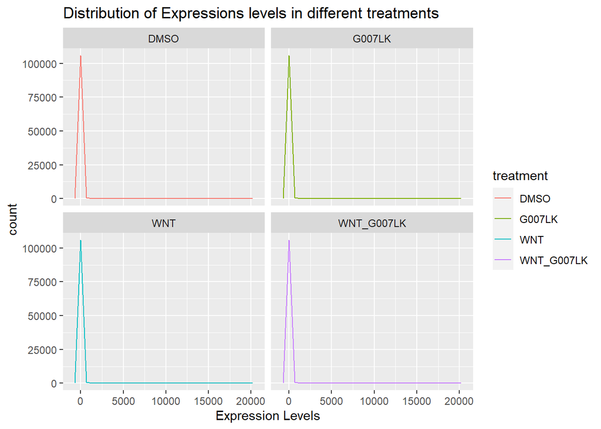

```r
freq_plot_mouse <- mouse_analysis |>
  ggplot( mapping = aes (x = expression_levels))+
  geom_freqpoly(aes(color = treatment))+
  facet_wrap(~treatment)+
  labs(title = "Distribution of Expressions levels in different treatments",
       x = "Expression Levels")

freq_plot_mouse
```

The bulk of zeros suggests that there is no difference in expression between the different conditions. This is a common observation for an RNA Seq data set, since many genes are not activated or remain inactive or unaffected by the studied conditions.

This is the distribution of the expression levels after transforming the data.

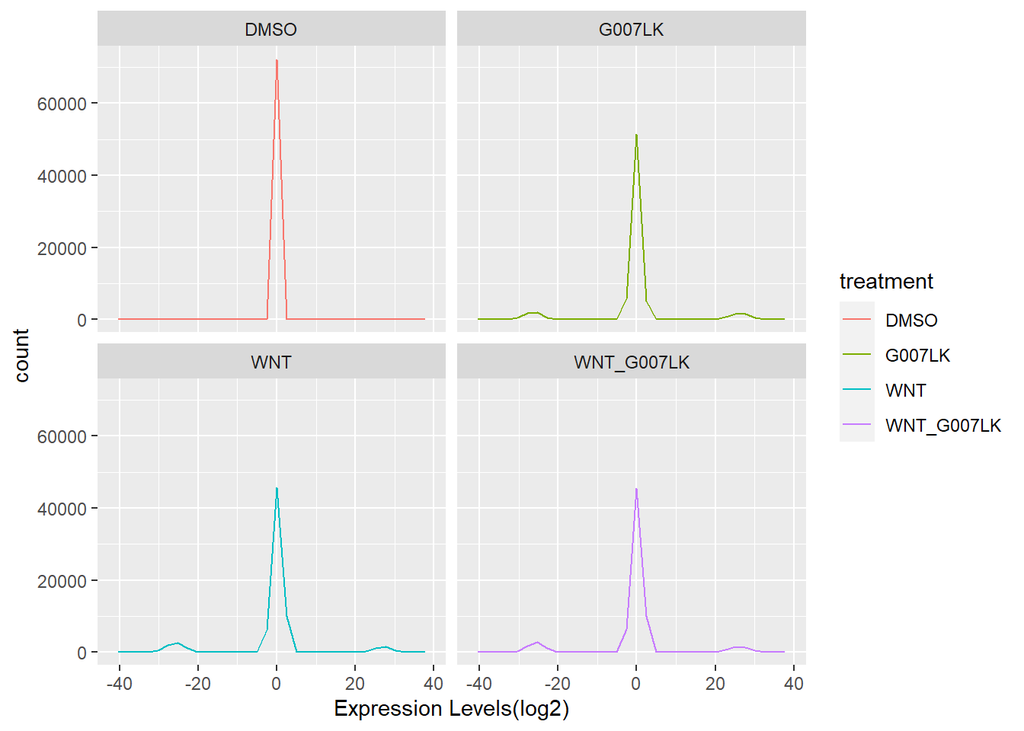

```r
mouse_analysis_aug <- mouse_aug |>
  pivot_longer(cols = -c(treatment, replicate),
               names_to = "gene",
               values_to = "expression_levels" )

freq_log_plot_mouse <- mouse_analysis_aug |>
  ggplot( mapping = aes (x = expression_levels))+
  geom_freqpoly(aes(color = treatment))+
  facet_wrap(~treatment)+
  labs(x = "Expression Levels(log2)")

freq_log_plot_mouse
```

```r
p1 <- freq_plot_mouse/freq_log_plot_mouse
ggsave("../results/04_key_plot_1.png",p1, bg = "white", device = "png")
```

Next, we want to check the summary statistics of the gene expression levels.

```r
mouse_statistics <- mouse_analysis |>
  group_by(gene) |>
  summarise(non_zero_count = sum(expression_levels != 0),
            zero_count = sum(expression_levels == 0),
            max_value = max(expression_levels),
            median_value = median(expression_levels),
            average_value = mean(expression_levels)
            )

knitr::kable(mouse_statistics[1:10, ])
```

| gene | non_zero_count | zero_count | max_value | median_value | average_value |
| --- | --- | --- | --- | --- | --- |
| ENSMUSG00000000001 | 12 | 0 | 76.5523323 | 72.538028 | 69.1868947 |
| ENSMUSG00000000003 | 0 | 12 | 0.0000000 | 0.000000 | 0.0000000 |
| ENSMUSG00000000028 | 12 | 0 | 57.6823830 | 49.702994 | 50.4525769 |
| ENSMUSG00000000037 | 12 | 0 | 4.3376154 | 2.355855 | 2.3361596 |
| ENSMUSG00000000049 | 3 | 9 | 0.1775317 | 0.000000 | 0.0263006 |
| ENSMUSG00000000056 | 12 | 0 | 22.0615083 | 10.343471 | 13.2134919 |
| ENSMUSG00000000058 | 12 | 0 | 155.3382656 | 108.501725 | 112.8261563 |
| ENSMUSG00000000078 | 12 | 0 | 48.6232612 | 45.414764 | 43.6271287 |
| ENSMUSG00000000085 | 12 | 0 | 31.7233557 | 21.259254 | 21.7247577 |
| ENSMUSG00000000088 | 12 | 0 | 539.3920604 | 505.630021 | 497.0781097 |

We can also get a crude look at the average expression levels for every experiment.

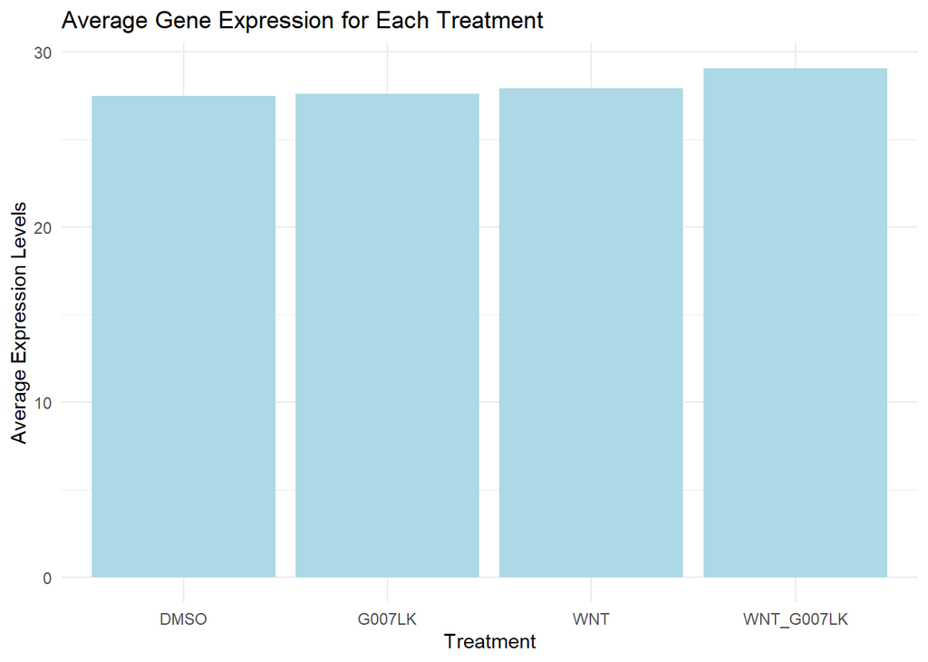

```r
 mouse_analysis |>
  group_by(treatment) |>
  summarise(average_expression_levels = mean(expression_levels,
                                             na.rm = TRUE)) |>
  ggplot(mapping = aes(x = treatment,
                       y = average_expression_levels)) +
  geom_bar(stat = "identity",
           fill = "light blue")+
  theme_minimal() +
  labs(title = "Average Gene Expression for Each Treatment",
       x = "Treatment",
       y = "Average Expression Levels")
```

They seem to be roughly the same, with the combined treatment (WNT+G007.LK) being slightly higher than the rest.

Let’s now look at the replicates within treatments as well.

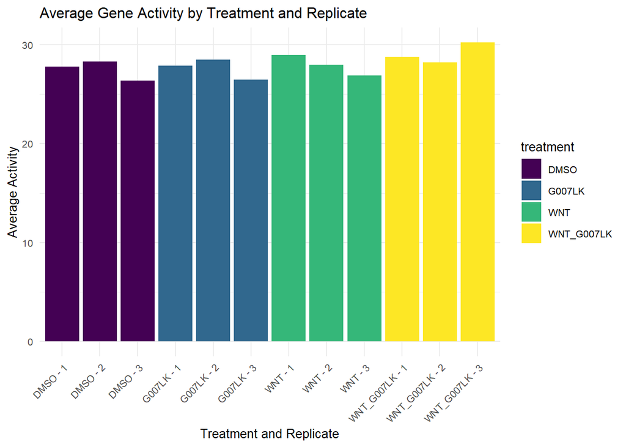

```r
# Calculate average activity for each treatment and replicate
average_activity_treatment_replicate <- mouse_wide |>
  pivot_longer(
    cols = -c(treatment, replicate),
    names_to = "gene",
    values_to = "activity") |>
  group_by(treatment, replicate) |>
  summarise(average_activity = mean(activity,
                                    na.rm = TRUE),
            .groups = "drop")  # Added .groups = "drop"

# Create a combined treatment and replicate label
average_activity_treatment_replicate <- average_activity_treatment_replicate |>
  mutate(treatment_replicate = paste(treatment,
                                     replicate,
                                     sep = " - "))

# Plot average activity for each treatment and replicate as a grouped bar plot with color by treatment
average_plot2 <- ggplot(average_activity_treatment_replicate,
       mapping = aes(x = treatment_replicate,
           y = average_activity,
           fill = treatment)) +
  geom_bar(stat = "identity",
           position = position_dodge(width = 0.8)) +
  scale_fill_viridis_d()+
  theme_minimal() +
  theme(text = element_text(size = 10),  # Reducing the text size
        axis.text.x = element_text(angle = 45,
                                   hjust = 1)) +  # Rotate x-axis labels for better readability
  labs(title = "Average Gene Activity by Treatment and Replicate",
       x = "Treatment and Replicate",
       y = "Average Activity")
average_plot2
```

These are also very similar. It would be hard to point out the treatment just by looking at the gene activity.

As we saw previously we have a lot of zeroes in our data set. But what is their distribution across the samples? For that matter we create the following histogram.

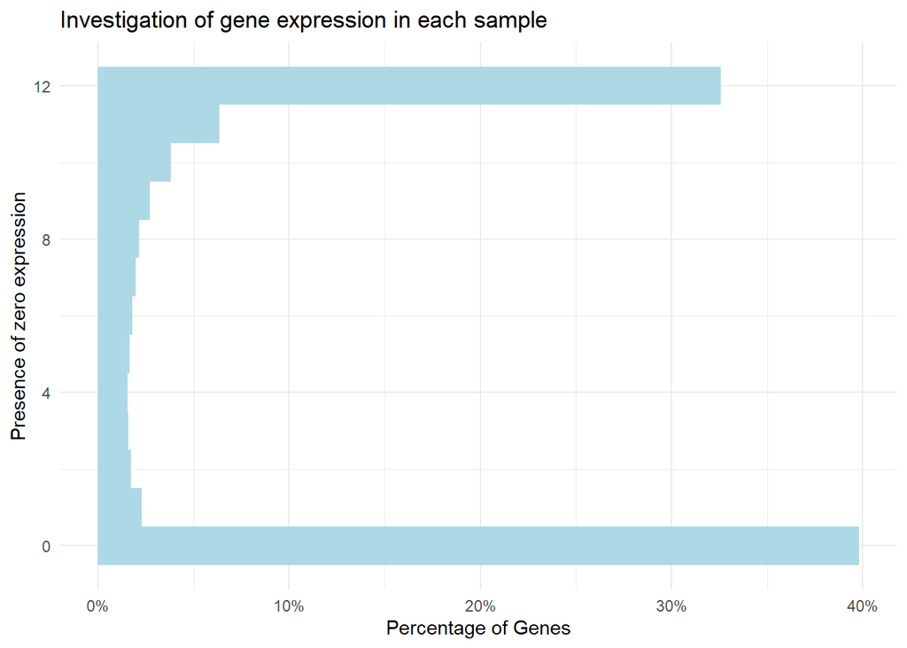

```r
#Calculate zero counts for each gene
zero_counts_genes <- mouse_analysis |>
  group_by(gene) |>
  summarise(zero_count = sum(expression_levels == 0))

#Create a histogram plot with percentages
mouse_zero_plot <- zero_counts_genes |>
  ggplot(aes(x = zero_count)) +
  geom_histogram(mapping = aes(y = after_stat(count/sum(count))),
                 binwidth = 1,
                 fill = "light blue") +
  scale_y_continuous(labels = scales::percent_format()) +
  theme_minimal() +
  labs(title = "Investigation of gene expression in each sample ",
       x = "Presence of zero expression",
       y = "Percentage of Genes")+
  coord_flip()
mouse_zero_plot
```

We can see that most genes either have all zeroes (~33%) or all non-zeroes( 40%).

```r
p2 <- average_plot2/ mouse_zero_plot
ggsave("../results/04_key_plot_2.png",p2, bg = "white", device = "png")
```

Let’s also compare the number of active genes in each treatment.

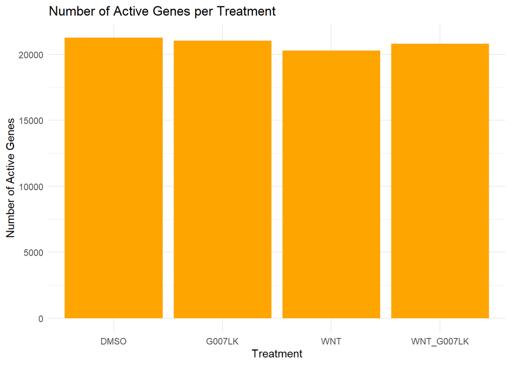

```r
#Determine active genes (non-zero activity) for each treatment

active_genes_per_treatment <- mouse_analysis |>
  filter(expression_levels > 0) |>
  group_by(treatment) |>
  summarise(active_genes = n_distinct(gene))

#Plot number of active genes per treatment

active_genes_plot <- active_genes_per_treatment |>
  ggplot(mapping = aes(x = treatment,
                       y = active_genes)) +
  geom_bar(stat = "identity",
           fill = "orange") +
  theme_minimal() +
  labs(title = "Number of Active Genes per Treatment",
       x = "Treatment",
       y = "Number of Active Genes")

active_genes_plot
```